# MSDM5051 Tutorial 8 - Computational Complexity

## Content

1. Notations
2. Complexity of Algorithms
3. Numerical Examples

# 1. Notations

## 1.1. The big-$O$ notation

The most commonly used notation for specifying asymptotic complexity is the big-$O$ notation introduced in 1894 by Paul Bachmann, with the following definition:

A function $f(n)$ is $O(g(n))$ if there exist positive numbers $c$ and $N$ such that $f(n) \leq cg(n)$ for all $n\geq N$

Informally, we can describe this relationship between $f$ and $g$ to be either that

1. $cg(n)$ is an upper bound of $f(n)$ when $n$ is large, or
2. $f$ grows at most as fast as $g$ in the long run.

Note that such definition is problematic that it states only that there must exist certain $c$ and $N$, but it does not give any hint how to determine these constants. In fact, there are usually infinitely many pairs of $c$s and $N$s that can be given for the same pair of functions $f$ and $g$. For example, consider the pair $f(n) = 2n^2+3n+1$ and $g(n) = n^2$ - the relation $f(n) \leq cg(n)$ holds when

| $n$ | $1$ | $2$ | $3$ | $4$ | $5$ | $\cdots$ | $\infty$ |
| --- | --- | --- | --- | --- | --- | --- | --- |
| $c$ | $\geq 6$ | $\geq 3.75$ | $\geq 3.11$ | $\geq 2.81$ | $\geq 2.64$ | $\cdots$ | $\geq 2$ |

Nevertheless, the exact values of these constants is irrelavent to describing the growth behavior of these two functions at large $N$ - all we want is knowing if values of $f$ is "comparable" to $g$ at abitrary large $N$, and which function's value is actually larger is not our concern at all. Thus you may think of the big-$O$ notation as a presentation tool simply made up for omitting these unimportant information.

## 1.2. Big-$\Omega$ & Big-$\Theta$

You may also see the other two notations when talking complexity:

- **Big-$\Omega$:**
  - *Definition:* $f(n)$ is $\Omega(g(n))$ if there exist positive numbers $c$ and $N$ such that $f(n)\geq cg(n)$ for all $n \geq N$.
  - *Meaning:* It is similar to big-$O$, but instead it specifies the lower bound of $f(n)$. i.e. $f$ grows at *least* as fast as $g$ in the long run.
- **Big-$\Theta$:**
  - *Definition:* $f(n)$ is $\Theta(g(n))$ if there exist positive numbers $c_1$, $c_2$, and $N$ such that $c_1g(n) \leq f(n) \leq c_2g(n)$ for all $n\geq N$.
  - *Meaning:* $f(n)$ is both $O(g(n))$ and $\Omega(g(n))$. i.e. $f$ is on the order of $g$, or both functions grow at the same rate in the long run

Other than the above 3, you may also find notations like $o$, $\omega$,... which have similar usage except the imposed conditions are stricter, and thus rarer. You may read more from the [wiki](https://en.wikipedia.org/wiki/Big_O_notation#Related_asymptotic_notations) if you are interested.

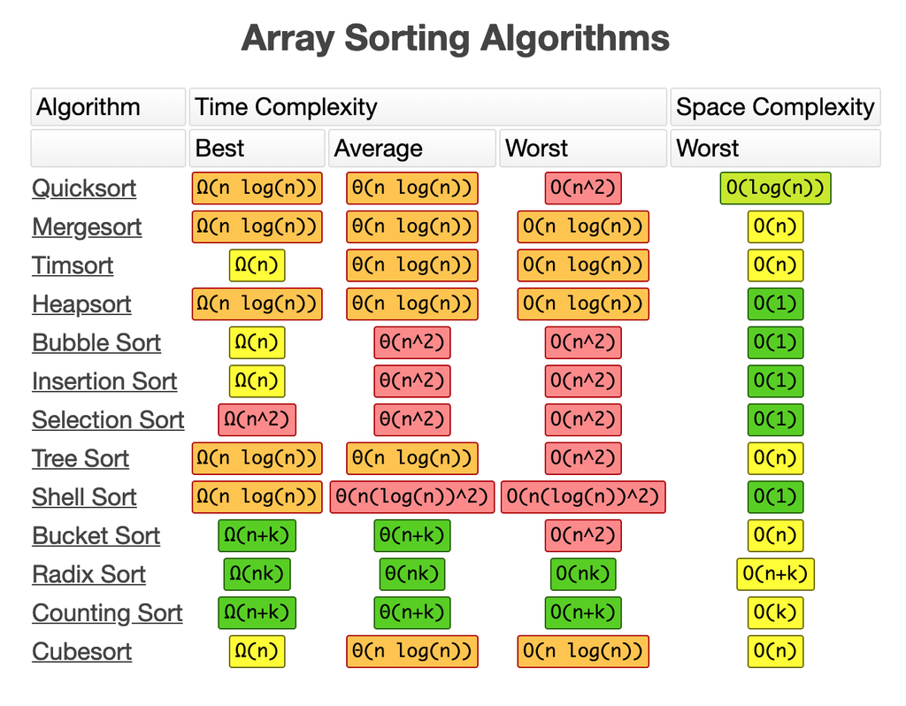

**Fig. 1** In fact, you have already seen $\Omega$ and $\Theta$ that are used for showing the complexity in the best and average scenario of sorting algorithms. Retrieved from https://www.bigocheatsheet.com/.

# 2. Complexity of Algorithms

## 2.1. Order of complexity

The complexities of algorithms are subdivided into these different groups, in the order of magnitude:

- $O(1)$
- $O(\log n)$ - The base of the log does not matter since $\log_a n = \frac{\log_b n}{\log_b a} = O(\log_b n) = O(\log_a n)$, for $a,b =$ some constants.
- $O(n)$
- $O(n\log n)$ and $O(\log n!)$ - These two are equivalent by the [Stirling approximation](https://en.wikipedia.org/wiki/Stirling%27s_approximation): $\log n! \approx n\log n - n$ when $n$ is large.
- $O(n^k)$ - i.e. Polynomial to the $k^\text{th}$ power.
- $O(k^n)$ - i.e. Exponential to base $k$.
- $O(n!)$

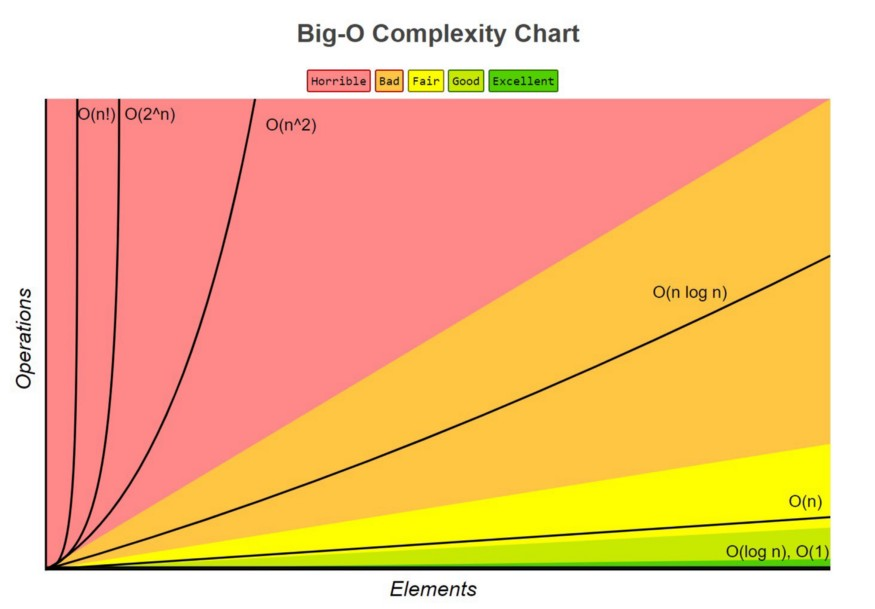

**Fig. 2** Trends of different Big-O classes. Retrieved from https://www.bigocheatsheet.com/.

Although algorithms with polynomial complexity $O(n^k)$ is classified as "horrible" in the above graph, they are necessary in many cases. For example, in a problem that requires to use $k$ nested loops is likely $O(n^k)$.

On the other hand, algorithms with exponential $O(k^n)$ and factorial $O(n!)$ are sometimes avoidable. The exponential / factorial factor usually comes from searching in a solution space of permulations/combinations. If the solutions from a big $n$ case can be related to a small $n$ case, the required time complexity can be reduced to polynomial time with tradeoffs, like what we did in dynamic programming.

## 2.2. The terminologies

In computation theory terms, complexity of algorithms can be divided into classes:

- **P** = Polynomial time, i.e. $\leq O(n^k)$ - We already found an algorithm that can solve this problem in polynomial time. But there may be an algorithm better than polynomial time for this problem.
- **NP** = Non-deterministic Polynomial time - We have not found an algorithm that can solve this problem in polynomial time. However we found an algorithm that can make guess and verify the guess in polynomial time. *Non-deterministic* means that the algorithm does not follow a fix sequence of steps/ involves randomness, thus may yield different solutions even when the same inputs are given each time.
- **EXP** = Exponential time, i.e. $\leq O(k^n)$ - We already found an algorithm that can solve this problem in exponential time. But there may be an algorithm better than exponential time for this problem.
- **R** = Any problem that can be solved in finite amount of time (but may take thousands of years).

Substitute NP or EXP into the XX below:

- XX-**Hard** - The problem is proven unable to be solved by any algorithms that cost less than XX time. The actual required algorithm may be even worse than XX.
- XX-**Complete** - We already found an algorithm that can solve this problem in XX time AND proven that this problem cannot be solved by any algorithms that cost less than XX time.

We may visualize them with a number line:

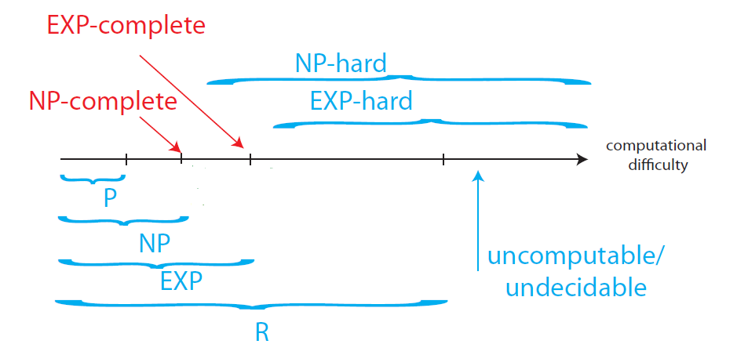

**Fig. 3** Sets of different computational complexity. Retrieved from [MIT opencourse 6.006 Introduction to Algorithm, Lecture 23](https://ocw.mit.edu/courses/6-006-introduction-to-algorithms-fall-2011/resources/mit6_006f11_lec23/) .

## 2.3. The P vs NP problem

The P vs NP problem is simply asking:

> If the solution of a problem can be verified within polynomial time

> Does it mean there is an algorithm that can solve this problem and runs in polynomial time?

The P vs NP problem is one of the most significant but unsolved in the field of computer science. If P = NP is true, it implies that all hard problems (up to NP) could in fact be solved by much more efficient algorithms (P) than those currently known. However up to today, it remains an open question and is recognized as one of the seven "Millennium Prize Problems" by the Clay Mathematics Institute, with a prize of $1,000,000 offered for its resolution.

# 3. Numerical Examples

## 3.1. Complexity of divide-and-conquer

In lecture, we have already seen several algorithms that are using the divide-and-conquer technique, e.g. quicksort, mergesort, etc. The main idea of divide-and-conquer is to divide the current task into multiple smaller sub-tasks and solve them recursively. In a general divide-and-conquer problem, we can describe the running time with the recurrence relation:

$$ T(n) = aT\left(\frac{n}{b}\right) + O(n^k) $$

For example in mergesort, sorting the original array (taking $T(n)$) is equivalent to sorting 2 arrays of half the size (taking $T\left(\frac{n}{2}\right)$, repeat twice) and additional steps to merge back the two arrays (taking $O(n)$). Therefore the running time of merge sort is

$$ T(n) = 2T\left(\frac{n}{2}\right) + O(n) $$

**Theorem:** The solution to the recurrance relation $T(n) = aT\left(\frac{n}{b}\right) + O(n^k)$ is

$$ T(n) = \begin{cases} n^{\log_ba} & \text{if } a>b^k\\ n^k\log n & \text{if } a=b^k\\ n^k & \text{if } a<b^k \end{cases} $$

**Proof:**

Let $n=b^m$. The recurrence relation becomes:

$$ \begin{aligned} T(b^m) &= aT(b^{m-1}) + O((b^{k})^m) \\[1.1ex] \frac{T(b^m)}{a^m} &= \frac{T(b^{m-1})}{a^{m-1}} + \left(\frac{O(b^k)}{a}\right)^m \\[1.1ex] &= \left[\frac{T(b^{m-2})}{a^{m-2}} + \left(\frac{O(b^k)}{a}\right)^{m-1}\right] + \left(\frac{O(b^k)}{a}\right)^m \\[1.1ex] &= \cdots \\[1.1ex] &= \frac{T(b^{0})}{a^{0}} + \sum_{i=1}^{m} \left(\frac{O(b^k)}{a}\right)^i \\[1.1ex] &= O\left[ 1+ \sum_{i=1}^{m} \left(\frac{b^k}{a}\right)^i \right] \end{aligned} $$

We see the running time depends on the geometric sum, whether each terms are smaller or larger than $1$.

- Case 1: $b^k<a$. The geometric sum converges to $\frac{\frac{b^k}{a}}{1-\frac{b^k}{a}}$ as $m$ increases, which is a constant independent of $m$. Therefore

  $$ \begin{aligned} T(n) &= a^m \cdot O(1) \\ &= O(a^{\log_b n}) \\ &= O(n^{\log_b a}) \end{aligned} $$
- Case 2: $b^k=a$. The sum equals to $m$. Therefore

  $$ \begin{aligned} T(n) &= O(a^m \cdot m) \\ &= O(n^{\log_b a} \cdot \log_b n) \\ &= O(n^{k} \log n) \end{aligned} $$
- Case 3: $b^k>a$. The sum equals to $\frac{\left(\frac{b^k}{a}\right)^{m+1} - 1}{\left(\frac{b^k}{a}\right)-1} \approx O\left(\frac{b^k}{a}\right)^{m}$. Therefore

  $$ \begin{aligned} T(n) &= O\left(a^m \cdot \left(\frac{b^k}{a}\right)^{m}\right) \\ &= O((b^m)^k) \\ &= O(n^{k}) \end{aligned} $$

## 3.2. Finding the i$^\text{th}$ element of a list (with distinct elements)

The most straight forward way to find the median is perhaps by sorting the list and look for the i$^\text{th}$ element, which gives a running time of $O(n\log n)$ (if there is no assumptions on the elements). However, it is actually possible to find it within $O(n)$ via this algorithm:

1. Divide the list into groups of 5, yielding total $\left\lceil\frac{n}{5}\right\rceil$ groups. Find the median of each group by sorting. Takes $O(5\log 5) = O(1)$ for each group, so at most $O(n)$.
2. Find the lower median of the medians (denote as $x$) from the $\left\lceil\frac{n}{5}\right\rceil$ groups.
3. Use $x$ as the pivot and divide the list into 3 sub-lists, just like quicksort:
   - All elements smaller than $x$. Assume having total $k-1$ elements.
   - $x$ itself
   - All elements larger than $x$. Assume having total $n-k$ elements.
4. Compare $k$ and $i$:
   - If $i=k$, finish
   - If $i<k$, repeat step 1-4 on the $k-1$ elements smaller than $x$.
   - If $i>k$, repeat step 1-4 on the $n-k$ elements larger than $x$.

The algorithm looks like quicksort at the first glance. However by analysis we can prove that it is $O(n)$. This is because when the pivot is chosen as the median of medians,

- At least half of the $\left\lceil\frac{n}{5}\right\rceil -2$ groups (those with median $>x$) must contain at least 3 elements that are larger than $x$.
- At least half of the $\left\lceil\frac{n}{5}\right\rceil -2$ groups (those with median $<x$) must contain at least 3 elements that are smaller than $x$.

The $-2$ comes from that we ignore the group containing $x$ and one group containing less than 5 elements (exist when $n$ cannot be divided by 5). So when we divide the list in step 3, each of the sub-lists are guarenteed to have at least $3 \left\lceil\left\lceil\frac{n}{5}\right\rceil -2\right\rceil \geq \frac{3n}{10}-6$ elements. Extreme cases, e.g. one of the sub-list containing only 1 element, will not appear.

Then we can analyze the running time of the algorithm. Let it be $T(n)$:

- In step 1, takes $O(n)$ to find the median of each group.
- In step 2, we can use the same algorithm to find the median of medians. Takes $T\left(\left\lceil\frac{n}{5}\right\rceil\right)$.
- In step 4, recursive running on one of the sub-lists takes at most $T\left(n - \left(\frac{3n}{10}-6\right)\right) = T\left(\frac{7n}{10}+6\right)$

Therefore we arrive at the recurrence relation:

$$ T(n) \leq O(n) + T\left(\left\lceil\frac{n}{5}\right\rceil\right) + T\left(\frac{7n}{10}+6\right) $$

To solve such inequality, we can first assume that $T(n)\leq cn$, which $c$ being some constant $\geq 0$, and then verify if it is really possible to find such $c$. We can also write $O(n) \leq an$ by definition of the big $O$ notation, with $a$ being some other constant $\geq 0$. Then,

$$ \begin{aligned} T(n) &\leq an + c\left\lceil\frac{n}{5}\right\rceil + c\left(\frac{7n}{10}+6\right) \\ &\leq an + c\left(\frac{n}{5}+1\right) + c\left(\frac{7n}{10}+6\right)\\ &= cn + \left(-\frac{cn}{10} + 7c + an\right) \end{aligned} $$

For $T(n)\leq cn$ to hold, we require $\left(-\frac{cn}{10} + 7c + an\right) \geq 0$, or equivalently $c \geq \frac{10an}{n-70}$.

- When $n<70$, $c$ is free to choose, including $0$. This means $T(n)$ does not depends on $n$, i.e. $O(1)$ in this domain.
- When $n>70$, $c$ has to be at least greater than $700a$, and converge to $10a$ when $n$ is large.

Just keep in mind that the size of $c$ is not important - it just tells us what upper bound we can at most determine for $T(n)$, while the true running time can be much smaller. Anyway, we have proven that the upper bound can always be expressed as $cn$, thus it is an algorithm of $O(n)$.